# Project_Final

#PCA(Principal_Component_Analysis)

```r
# prcomp is the principal component function
pca <- prcomp(data2[,10:14], scale = TRUE)
pca
```

```
## Standard deviations (1, .., p=5):
## [1] 1.3429780 1.0370768 0.9399448 0.8710437 0.6918587
##
## Rotation (n x k) = (5 x 5):
##                 PC1        PC2        PC3        PC4        PC5
## age       0.5635382 -0.1059946 -0.1692945 -0.5419762  0.5905854
## trestbps  0.3671043 -0.4530454  0.7306853 -0.1215011 -0.3336476
## chol      0.2644374 -0.6602155 -0.5618229  0.3814106 -0.1818500
## thalach  -0.5044408 -0.4968335  0.2629944  0.1778681  0.6307874
## oldpeak   0.4725161  0.3174696  0.2294065  0.7172086  0.3300395
```

```r
# Variance of principal components
variance <- pca$sdev^2

# Proportion of variance explained by each principal component
variance_proportion <- variance / sum(variance)

# Print variance and proportion of variance explained
print(variance)
```

```
## [1] 1.8035898 1.0755283 0.8834962 0.7587172 0.4786685
```

```r
summary(pca)
```

```
## Importance of components:
##                           PC1    PC2    PC3    PC4     PC5
## Standard deviation     1.3430 1.0371 0.9399 0.8710 0.69186
## Proportion of Variance 0.3607 0.2151 0.1767 0.1517 0.09573
## Cumulative Proportion  0.3607 0.5758 0.7525 0.9043 1.00000
```

This result summarizes the importance of each principal component (PC) in a principal component analysis (PCA). The “Standard deviation” column represents the variability explained by each PC, with PC1 explaining the most and PC5 the least. “Proportion of Variance” indicates the proportion of total variance explained by each PC, with PC1 contributing the most variance and PC5 the least. “Cumulative Proportion” shows the cumulative proportion of variance explained by the PCs, indicating that the first PC alone explains 36.07% of the variance, while all five PCs combined explain 100% of the variance in the dataset.

```r
pca$sdev
```

```
## [1] 1.3429780 1.0370768 0.9399448 0.8710437 0.6918587
```

```r
#Eigen vectors
pca$rotation
```

```
##                 PC1        PC2        PC3        PC4        PC5
## age       0.5635382 -0.1059946 -0.1692945 -0.5419762  0.5905854
## trestbps  0.3671043 -0.4530454  0.7306853 -0.1215011 -0.3336476
## chol      0.2644374 -0.6602155 -0.5618229  0.3814106 -0.1818500
## thalach  -0.5044408 -0.4968335  0.2629944  0.1778681  0.6307874
## oldpeak   0.4725161  0.3174696  0.2294065  0.7172086  0.3300395
```

```r
#std deviation and mean of variables
pca$center
```

```
##        age   trestbps       chol    thalach    oldpeak
##  54.434146 131.611707 246.000000 149.114146   1.071512
```

```r
pca$scale
```

```
##       age  trestbps      chol   thalach   oldpeak
##  9.072290 17.516718 51.592510 23.005724  1.175053
```

```r
# Principal component scores (showing only first 5 rows)
head(pca$x, 5)
```

```
##             PC1        PC2        PC3         PC4        PC5
## [1,] -0.9068936  0.2073491  0.3418077  0.04228957  0.5850594
## [2,]  0.5529602  0.7709982  1.3082301  0.99322312  0.6295568
## [3,]  2.0218277  1.3269638  1.0748005 -0.80854906  0.7802009
## [4,] -0.1605916 -0.4964952  0.9560288 -1.38592049  0.2917687
## [5,]  2.1283769  0.2870713 -0.7285281  0.03090104 -0.7477833
```

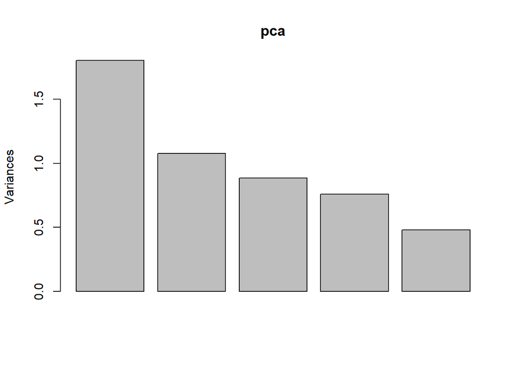

```r
screeplot(pca)
```

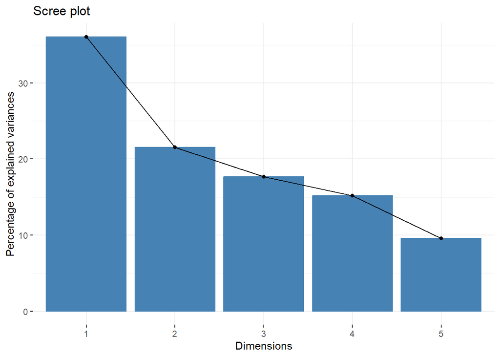

```r
library(factoextra)
fviz_screeplot(pca)
```

# In order to break into pieces each variable contribution on each Principal Component we can use fviz_contrib function.

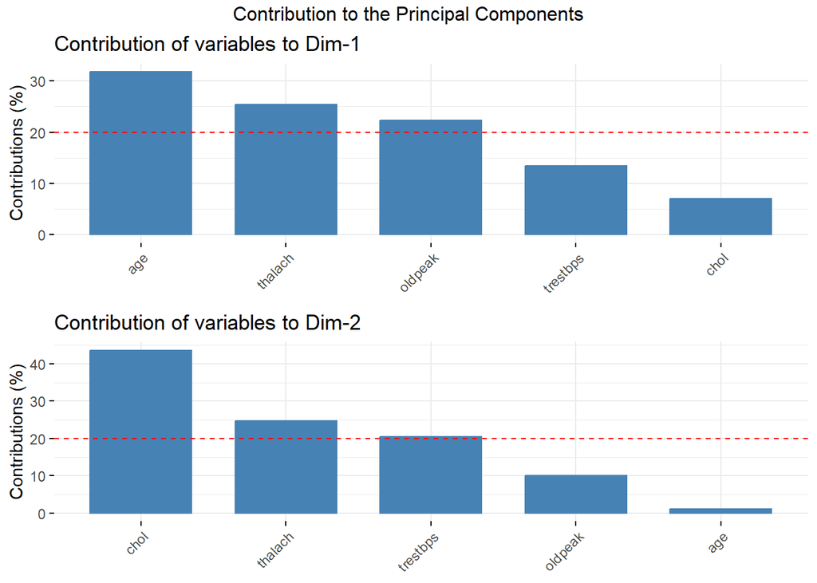

```r
var <- get_pca_var(pca)
a<-fviz_contrib(pca, "var",axes = 1)
b<-fviz_contrib(pca, "var",axes = 2)
grid.arrange(a,b,top='Contribution to the Principal Components')
```

In the first graph, “Contribution of variables to Dim-1,” we see that several variables contribute to the first principal component, with their contributions shown in percentages. The variables are labeled along the x-axis (though the text is slightly obscured, possibly due to resolution issues), and the y-axis shows the percentage contribution. A dashed red line appears to indicate an average level of contribution across the variables. The first variable on the x-axis appears to contribute around 30%, which is the highest among all the variables shown.

# Print variance and proportion_variance

```r
# Variance of the first two principal components
variance <- (pca$sdev[1:2])^2

# Proportion of variance explained by the first two principal components
variance_proportion <- variance / sum(variance)

# Print variance and proportion of variance explained
print(variance)
```

```
## [1] 1.803590 1.075528
```

```r
print(variance_proportion)
```

```
## [1] 0.6264383 0.3735617
```

Inference First 2 Principal components: 1st PC: 62% 2nd PC: 37%